# dfply & plotnine Exercise Solution

```python
from IPython.core.display import HTML
HTML('''<script>
function code_toggle() {
 $('div.input').hide();
}
$( document ).ready(code_toggle);
</script>
''')
```

dfply & plotnine Quiz

#### 문제 1. `dfply` 이용하기

#### 문제 2. `plotnine` 이용하기

### 다음 Packages를 load하여 진행하시오.

```
import pandas as pd
from dfply import *
from plotnine import *
from plotnine.themes import theme
from plotnine.facets import facet_wrap

import warnings
warnings.filterwarnings(action="ignore")
```

```python
import pandas as pd
from dfply import *
from plotnine import *
from plotnine.themes import theme
from plotnine.facets import facet_wrap
```

```python
import warnings
warnings.filterwarnings(action="ignore")
```

[figure not shown]

### Description

- **Country** : 국가명
- **DR(Dystopia Residual)** : Dystopia Residual 행복지수에 기여하는 정도
- **Economy** : GDP가 행복지수에 기여하는 정도
- **Family** : 가정이 행복지수에 기여하는 정도
- **Freedom** : 자유도가 행복지수에 기여하는 정도
- **Generosity** : 너그러움이 행복지수에 기여하는 정도
- **H_Rank** : 행복지수 순위
- **H_Score** : 행복지수
- **Health** : 건강이 행복지수에 기여하는 정도
- **Region** : 국가에 속해 있는 지역명
- **Trust** : 정부 신뢰도가 행복지수에 기여하는 정도
- **year** : 조사 년도

### Data Load

```
Happy = pd.read_csv("../Data/Happiness.csv")
Happy.head()
```

```python
Happy = pd.read_csv("../Data/Happiness.csv")
Happy.head()
```

|  | Country | DR | Economy | Family | Freedom | Generosity | H_Rank | H_Score | Health | Region | Trust | year |
| --- | --- | --- | --- | --- | --- | --- | --- | --- | --- | --- | --- | --- |
| 0 | Switzerland | 2.51738 | 1.39651 | 1.34951 | 0.66557 | 0.29678 | 1 | 7.587 | 0.94143 | Western Europe | 0.41978 | 2015 |
| 1 | Iceland | 2.70201 | 1.30232 | 1.40223 | 0.62877 | 0.43630 | 2 | 7.561 | 0.94784 | Western Europe | 0.14145 | 2015 |
| 2 | Denmark | 2.49204 | 1.32548 | 1.36058 | 0.64938 | 0.34139 | 3 | 7.527 | 0.87464 | Western Europe | 0.48357 | 2015 |
| 3 | Norway | 2.46531 | 1.45900 | 1.33095 | 0.66973 | 0.34699 | 4 | 7.522 | 0.88521 | Western Europe | 0.36503 | 2015 |
| 4 | Canada | 2.45176 | 1.32629 | 1.32261 | 0.63297 | 0.45811 | 5 | 7.427 | 0.90563 | North America | 0.32957 | 2015 |

## 문제 1. `dfply` 이용하기

### 1.1 Region 별 개수를 구하시오.

- hint : `summarize()`, `n()`

```python
(Happy >>
 group_by(X.Region) >>
 summarize(Count = n(X.Region)))
```

|  | Region | Count |
| --- | --- | --- |
| 0 | Australia and New Zealand | 6 |
| 1 | Central and Eastern Europe | 87 |
| 2 | Eastern Asia | 16 |
| 3 | Latin America and Caribbean | 68 |
| 4 | Middle East and Northern Africa | 58 |
| 5 | North America | 6 |
| 6 | Southeastern Asia | 26 |
| 7 | Southern Asia | 21 |
| 8 | Sub-Saharan Africa | 117 |
| 9 | Western Europe | 63 |

### 1.2 Region 별 개수를 구하고 내림차순으로 정렬하시오.

- hint : `ungroup()`

```python
(Happy >>
 group_by(X.Region) >>
 summarize(Count = n(X.Region)) >>
 ungroup() >>
 arrange(X.Count, ascending=False))
```

|  | Region | Count |
| --- | --- | --- |
| 8 | Sub-Saharan Africa | 117 |
| 1 | Central and Eastern Europe | 87 |
| 3 | Latin America and Caribbean | 68 |
| 9 | Western Europe | 63 |
| 4 | Middle East and Northern Africa | 58 |
| 6 | Southeastern Asia | 26 |
| 7 | Southern Asia | 21 |
| 2 | Eastern Asia | 16 |
| 0 | Australia and New Zealand | 6 |
| 5 | North America | 6 |

### 1.3 Region별 정부 평균신뢰도를 구하고 가장작은 3곳을 출력하시오.

- `head()` 출력

```python
(Happy >>
 group_by(X.Region) >>
 summarize(Mean_Trust = mean(X.Trust)) >>
 ungroup() >>
 arrange(X.Mean_Trust, ascending=True) >>
 head())
```

|  | Region | Mean_Trust |
| --- | --- | --- |
| 1 | Central and Eastern Europe | 0.084788 |
| 7 | Southern Asia | 0.103500 |
| 3 | Latin America and Caribbean | 0.103720 |
| 2 | Eastern Asia | 0.109937 |
| 8 | Sub-Saharan Africa | 0.114975 |

### 1.4 `South Korea`의 `2016`년 행복지수와 순위를 구하시오.

```python
(Happy >>
 mask(X.Country == "South Korea", X.year == 2016) >>
 select(X.Country, X.H_Rank, X.H_Score))
```

[output not shown]

### 1.5 `Country`별 3개년 `H_Score` 합산 상위 5개국을 출력하시오.

- `head()` 출력

```python
(Happy >>
 group_by(X.Country) >>
 summarize(Sum_H_Score = X.H_Score.sum()) >>
 ungroup() >>
 arrange(X.Sum_H_Score, ascending = False) >>
 head())
```

|  | Country | Sum_H_Score |
| --- | --- | --- |
| 141 | Switzerland | 22.590 |
| 38 | Denmark | 22.575 |
| 59 | Iceland | 22.566 |
| 107 | Norway | 22.557 |
| 46 | Finland | 22.288 |

### 1.6. 2015년에 비해 행복지수 순위가 가장 높아진 국가 상위5개를 출력하시오.

- Step 별로 진행할 것

#### Step1

- `mutate()`와 `first()` 함수를 활용하여 H_diff변수 만들기
- `H_diff` 는 연도별 `H_Rank`에서 2015년 `H_Rank` 값을 뺀 변수
- `head()` 출력

```python
(Happy >> group_by(X.Country) >>
 mutate(H_diff=X.H_Rank-first(X.H_Rank)) >>
 ungroup() >>
 head())
```

|  | Country | DR | Economy | Family | Freedom | Generosity | H_Rank | H_Score | Health | Region | Trust | year | H_diff |
| --- | --- | --- | --- | --- | --- | --- | --- | --- | --- | --- | --- | --- | --- |
| 152 | Afghanistan | 1.952100 | 0.319820 | 0.302850 | 0.23414 | 0.365100 | 153 | 3.575 | 0.303350 | Southern Asia | 0.097190 | 2015 | 0 |
| 311 | Afghanistan | 2.145580 | 0.382270 | 0.110370 | 0.16430 | 0.312680 | 154 | 3.360 | 0.173440 | Southern Asia | 0.071120 | 2016 | 1 |
| 453 | Afghanistan | 2.150801 | 0.401477 | 0.581543 | 0.10618 | 0.311871 | 141 | 3.794 | 0.180747 | Southern Asia | 0.061158 | 2017 | -12 |
| 94 | Albania | 1.898940 | 0.878670 | 0.804340 | 0.35733 | 0.142720 | 95 | 4.959 | 0.813250 | Central and Eastern Europe | 0.064130 | 2015 | 0 |
| 266 | Albania | 1.928160 | 0.955300 | 0.501630 | 0.31866 | 0.168400 | 109 | 4.655 | 0.730070 | Central and Eastern Europe | 0.053010 | 2016 | 14 |

#### Step2

- `Country`, `year` 변수들과 `H`로 시작하는 변수들을 선택하기
- `head()` 출력

```python
(Happy >> group_by(X.Country) >>
 mutate(H_diff=X.H_Rank-first(X.H_Rank)) >>
 ungroup() >>
 select(['Country', 'year'], starts_with('H')) >>
 head())
```

|  | Country | year | H_Rank | H_Score | Health | H_diff |
| --- | --- | --- | --- | --- | --- | --- |
| 152 | Afghanistan | 2015 | 153 | 3.575 | 0.303350 | 0 |
| 311 | Afghanistan | 2016 | 154 | 3.360 | 0.173440 | 1 |
| 453 | Afghanistan | 2017 | 141 | 3.794 | 0.180747 | -12 |
| 94 | Albania | 2015 | 95 | 4.959 | 0.813250 | 0 |
| 266 | Albania | 2016 | 109 | 4.655 | 0.730070 | 14 |

#### Step3

- `2017`년 데이터만 필터링하기
- `head()` 출력

```python
(Happy >> group_by(X.Country) >>
 mutate(H_diff=X.H_Rank-first(X.H_Rank)) >>
 ungroup() >>
 select(['Country', 'year'], starts_with('H')) >>
 mask(X.year == 2017) >>
 head())
```

|  | Country | year | H_Rank | H_Score | Health | H_diff |
| --- | --- | --- | --- | --- | --- | --- |
| 453 | Afghanistan | 2017 | 141 | 3.794 | 0.180747 | -12 |
| 421 | Albania | 2017 | 109 | 4.644 | 0.731160 | 14 |
| 366 | Algeria | 2017 | 53 | 5.872 | 0.617585 | -15 |
| 452 | Angola | 2017 | 140 | 3.795 | 0.049869 | 3 |
| 338 | Argentina | 2017 | 24 | 6.599 | 0.695137 | -6 |

#### Step4

- `H_diff`기준 오름차순으로 정렬하기
- `head()` 출력

```python
(Happy >> group_by(X.Country) >>
 mutate(H_diff=X.H_Rank-first(X.H_Rank)) >>
 ungroup() >>
 select(['Country', 'year'], starts_with('H')) >>
 mask(X.year == 2017) >>
 arrange(X.H_diff) >>
 head())
```

|  | Country | year | H_Rank | H_Score | Health | H_diff |
| --- | --- | --- | --- | --- | --- | --- |
| 367 | Latvia | 2017 | 54 | 5.850 | 0.638567 | -35 |
| 416 | Egypt | 2017 | 104 | 4.735 | 0.520187 | -31 |
| 417 | Bulgaria | 2017 | 105 | 4.714 | 0.708218 | -29 |
| 387 | Hungary | 2017 | 75 | 5.324 | 0.687763 | -29 |
| 370 | Romania | 2017 | 57 | 5.825 | 0.685158 | -29 |

### 1.7. 2015년에 비해 행복지수 순위가 가장 떨어진 국가 상위 5개를 출력하시오.

- `head()` 출력

```python
(Happy >> group_by(X.Country) >>
 mutate(H_diff=X.H_Rank-first(X.H_Rank)) >>
 ungroup() >>
 select(['Country', 'year'], starts_with('H')) >>
 mask(X.year == 2017) >>
 arrange(X.H_diff, ascending=False) >>
 head())
```

|  | Country | year | H_Rank | H_Score | Health | H_diff |
| --- | --- | --- | --- | --- | --- | --- |
| 394 | Venezuela | 2017 | 82 | 5.250 | 0.617144 | 59 |
| 451 | Lesotho | 2017 | 139 | 3.808 | 0.000000 | 42 |
| 460 | Liberia | 2017 | 148 | 3.533 | 0.229918 | 32 |
| 428 | Zambia | 2017 | 116 | 4.514 | 0.257836 | 31 |
| 457 | Haiti | 2017 | 145 | 3.603 | 0.277321 | 26 |

### 1.8 `year`, `Region` 별 `H_Score` 평균과 분산을 구하시오.

- `head()` 출력

```python
(Happy >>
 group_by(X.year, X.Region) >>
 summarize(mean_score=mean(X['H_Score']),
           var_score=var(X['H_Score'])) >>
 ungroup() >>
 head())
```

|  | Region | year | mean_score | var_score |
| --- | --- | --- | --- | --- |
| 0 | Australia and New Zealand | 2015 | 7.285000 | 0.000002 |
| 1 | Central and Eastern Europe | 2015 | 5.332931 | 0.325408 |
| 2 | Eastern Asia | 2015 | 5.626167 | 0.306975 |
| 3 | Latin America and Caribbean | 2015 | 6.144682 | 0.530800 |
| 4 | Middle East and Northern Africa | 2015 | 5.406900 | 1.213042 |

### 1.9 2017년에 `Family`가 `H_Score`에 차지하는 비율이 가장 높은 국가 3곳

- step별로 진행할 것

#### Step1

- `mutate()`함수를 활용하여 `Family_Prop`변수 만들기
- `Family_Prop` = `Family` / `H_Score`
- `head()` 출력

```python
(Happy >>
 mask(X.year == 2017) >>
 mutate(Family_Prop = (X.Family/X.H_Score)) >>
 head())
```

|  | Country | DR | Economy | Family | Freedom | Generosity | H_Rank | H_Score | Health | Region | Trust | year | Family_Prop |
| --- | --- | --- | --- | --- | --- | --- | --- | --- | --- | --- | --- | --- | --- |
| 315 | Norway | 2.277027 | 1.616463 | 1.533524 | 0.635423 | 0.362012 | 1 | 7.537 | 0.796667 | Western Europe | 0.315964 | 2017 | 0.203466 |
| 316 | Denmark | 2.313707 | 1.482383 | 1.551122 | 0.626007 | 0.355280 | 2 | 7.522 | 0.792566 | Western Europe | 0.400770 | 2017 | 0.206211 |
| 317 | Iceland | 2.322715 | 1.480633 | 1.610574 | 0.627163 | 0.475540 | 3 | 7.504 | 0.833552 | Western Europe | 0.153527 | 2017 | 0.214629 |
| 318 | Switzerland | 2.276716 | 1.564980 | 1.516912 | 0.620071 | 0.290549 | 4 | 7.494 | 0.858131 | Western Europe | 0.367007 | 2017 | 0.202417 |
| 319 | Finland | 2.430182 | 1.443572 | 1.540247 | 0.617951 | 0.245483 | 5 | 7.469 | 0.809158 | Western Europe | 0.382612 | 2017 | 0.206219 |

#### Step2

- `Family_Prop`기준 내림차순 정렬
- `head()` 출력

```python
(Happy >>
 mask(X.year == 2017) >>
 mutate(Family_Prop = (X.Family/X.H_Score)) >>
 arrange(X.Family_Prop, ascending=False) >>
 head())
```

|  | Country | DR | Economy | Family | Freedom | Generosity | H_Rank | H_Score | Health | Region | Trust | year | Family_Prop |
| --- | --- | --- | --- | --- | --- | --- | --- | --- | --- | --- | --- | --- | --- |
| 444 | Ukraine | 0.814382 | 0.894652 | 1.394538 | 0.122975 | 0.270061 | 132 | 4.096 | 0.575904 | Central and Eastern Europe | 0.023029 | 2017 | 0.340463 |
| 454 | Botswana | 0.377914 | 1.122094 | 1.221555 | 0.505196 | 0.099348 | 142 | 3.766 | 0.341756 | Sub-Saharan Africa | 0.098583 | 2017 | 0.324364 |
| 451 | Lesotho | 1.429835 | 0.521021 | 1.190095 | 0.390661 | 0.157497 | 139 | 3.808 | 0.000000 | Sub-Saharan Africa | 0.119095 | 2017 | 0.312525 |
| 465 | Tanzania | 0.621130 | 0.511136 | 1.041990 | 0.390018 | 0.354256 | 153 | 3.349 | 0.364509 | Sub-Saharan Africa | 0.066035 | 2017 | 0.311135 |
| 439 | Mali | 1.668191 | 0.476180 | 1.281473 | 0.306614 | 0.183354 | 127 | 4.190 | 0.169366 | Sub-Saharan Africa | 0.104970 | 2017 | 0.305841 |

#### Step3

- `Country`, `Family`, `Family_Prop`변수만 선택하기
- `head()` 출력

```python
(Happy >>
 mask(X.year == 2017) >>
 mutate(Family_Prop = (X.Family/X.H_Score)) >>
 arrange(X.Family_Prop, ascending=False) >>
 select(X.Country, starts_with('Family')) >>
 head())
```

|  | Country | Family | Family_Prop |
| --- | --- | --- | --- |
| 444 | Ukraine | 1.394538 | 0.340463 |
| 454 | Botswana | 1.221555 | 0.324364 |
| 451 | Lesotho | 1.190095 | 0.312525 |
| 465 | Tanzania | 1.041990 | 0.311135 |
| 439 | Mali | 1.281473 | 0.305841 |

## 문제 2. `plotnine` 이용하기

### Data Load

```
Happy = pd.read_csv("../Data/Happiness.csv")
Happy.head()
```

```python
Happy = pd.read_csv("../Data/Happiness.csv")
Happy.head()
```

|  | Country | DR | Economy | Family | Freedom | Generosity | H_Rank | H_Score | Health | Region | Trust | year |
| --- | --- | --- | --- | --- | --- | --- | --- | --- | --- | --- | --- | --- |
| 0 | Switzerland | 2.51738 | 1.39651 | 1.34951 | 0.66557 | 0.29678 | 1 | 7.587 | 0.94143 | Western Europe | 0.41978 | 2015 |
| 1 | Iceland | 2.70201 | 1.30232 | 1.40223 | 0.62877 | 0.43630 | 2 | 7.561 | 0.94784 | Western Europe | 0.14145 | 2015 |
| 2 | Denmark | 2.49204 | 1.32548 | 1.36058 | 0.64938 | 0.34139 | 3 | 7.527 | 0.87464 | Western Europe | 0.48357 | 2015 |
| 3 | Norway | 2.46531 | 1.45900 | 1.33095 | 0.66973 | 0.34699 | 4 | 7.522 | 0.88521 | Western Europe | 0.36503 | 2015 |
| 4 | Canada | 2.45176 | 1.32629 | 1.32261 | 0.63297 | 0.45811 | 5 | 7.427 | 0.90563 | North America | 0.32957 | 2015 |

### 2.1 `Region`별 국가 수 를 그리시오.

- step별로 진행할 것

#### Step1

- hint : fill = 'Region'

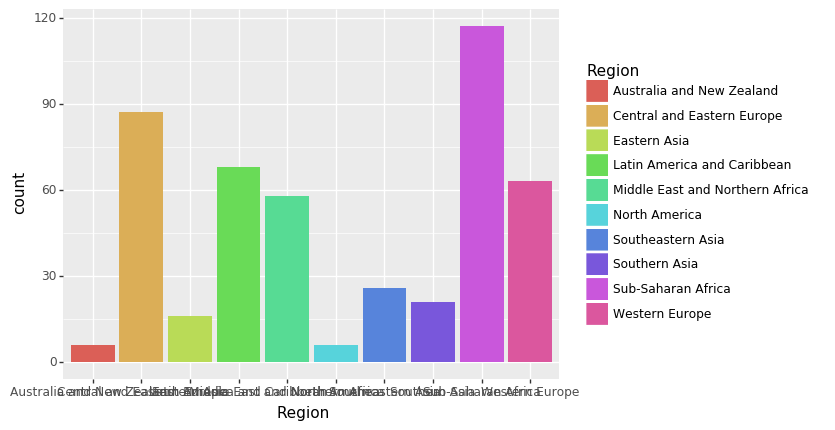

```python
(ggplot(Happy, aes('Region', fill='Region')) +
    geom_bar())
```

#### Step2

- `theme` 함수를 이용하여 x축 값 45º 회전하기

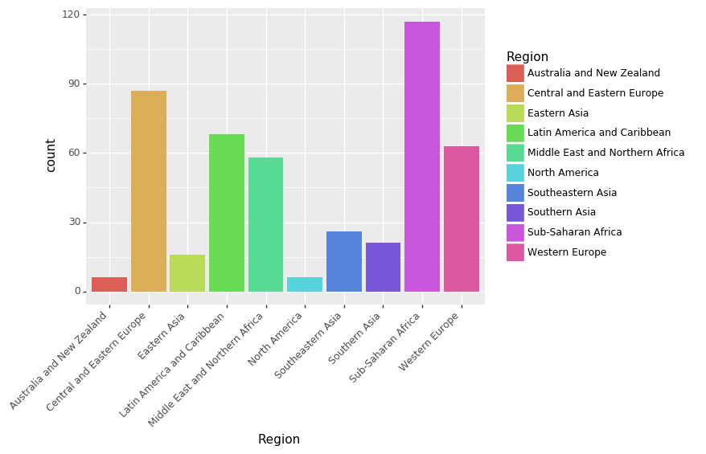

```python
(ggplot(Happy, aes('Region', fill='Region')) +
    geom_bar() +
    theme(axis_text_x = element_text(angle = 45, hjust = 1)))
```

### 2.2 `Trust`(정부신뢰도) Region별 Boxplot을 그리시오.

- step별로 진행할 것

#### Step1

- hint : fill = 'Region', color = 'Region'
- theme 함수를 이용하여 x축 값 45º 회전하기

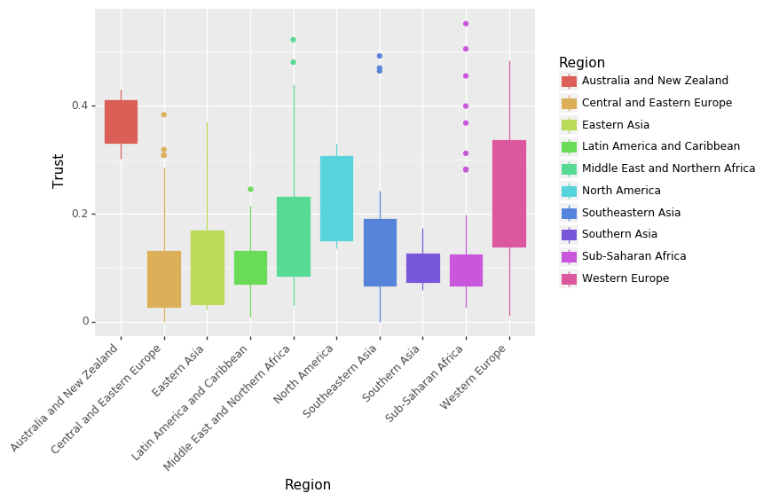

```python
(ggplot(Happy, aes('Region', 'Trust', fill='Region', color='Region')) +
    geom_boxplot()  +
    theme(axis_text_x = element_text(angle = 45, hjust = 1)))
```

#### Step2

- `geom_jitter()` 활용하기
- `geom_jitter`의 `alpha`는 0.3으로 주기

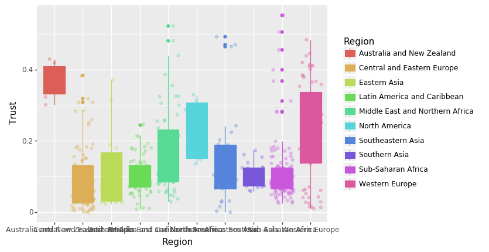

```python
(ggplot(Happy, aes('Region', 'Trust', fill='Region', color='Region')) +
    geom_boxplot() +
    geom_jitter(alpha=0.3))
```

#### Step3

- `coord_flip()`활용하여 x, y축 바꾸기

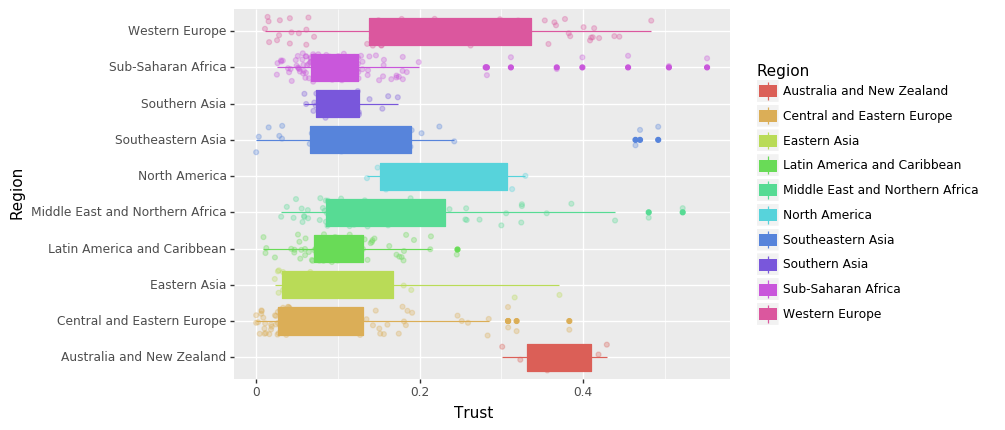

```python
(ggplot(Happy, aes('Region', 'Trust', fill='Region', color='Region')) +
    geom_boxplot() +
    geom_jitter(alpha=0.3) +
    coord_flip())
```

### 2.3 2017년 기준 상위 10개국에서 `H_Score`에 영향을 주는 요인들 비중을 그리시오.

- step별로 진행할 것

#### Step1

- `year`이 2017년이고 H_rank가 10이하 필터링
- `head()` 출력

```python
Happy2 = Happy >> mask(X.H_Rank <=10, X.year == 2017)
Happy2.head()
```

|  | Country | DR | Economy | Family | Freedom | Generosity | H_Rank | H_Score | Health | Region | Trust | year |
| --- | --- | --- | --- | --- | --- | --- | --- | --- | --- | --- | --- | --- |
| 315 | Norway | 2.277027 | 1.616463 | 1.533524 | 0.635423 | 0.362012 | 1 | 7.537 | 0.796667 | Western Europe | 0.315964 | 2017 |
| 316 | Denmark | 2.313707 | 1.482383 | 1.551122 | 0.626007 | 0.355280 | 2 | 7.522 | 0.792566 | Western Europe | 0.400770 | 2017 |
| 317 | Iceland | 2.322715 | 1.480633 | 1.610574 | 0.627163 | 0.475540 | 3 | 7.504 | 0.833552 | Western Europe | 0.153527 | 2017 |
| 318 | Switzerland | 2.276716 | 1.564980 | 1.516912 | 0.620071 | 0.290549 | 4 | 7.494 | 0.858131 | Western Europe | 0.367007 | 2017 |
| 319 | Finland | 2.430182 | 1.443572 | 1.540247 | 0.617951 | 0.245483 | 5 | 7.469 | 0.809158 | Western Europe | 0.382612 | 2017 |

#### Step2

- Tidy data로 만들기
- id_var: `Country`
- melt_vars: `DR`, `Economy`, `Family`, `Freedom`, `Generosity`, `Health`, `Trust`
- `select('Country', 'variable', 'value')` 후 `head()` 출력

```python
Happy3 = (Happy2 >>
          gather('variable', 'value', ['DR', 'Economy', 'Family', 'Freedom', 'Generosity', 'Health',  'Trust']) >>
          select('Country', 'variable', 'value'))
Happy3.head()
```

|  | Country | variable | value |
| --- | --- | --- | --- |
| 0 | Norway | DR | 2.277027 |
| 1 | Denmark | DR | 2.313707 |
| 2 | Iceland | DR | 2.322715 |
| 3 | Switzerland | DR | 2.276716 |
| 4 | Finland | DR | 2.430182 |

#### Step3

- `geom_bar()`를 이용하여 plot 그리기
- `geom_bar()`의 옵션은 `stat`='identity', `position`='fill'

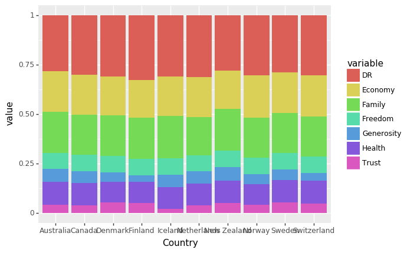

```python
(ggplot(Happy3, aes('Country', 'value', fill='variable')) +
    geom_bar(stat='identity', position='fill'))
```

#### Step4

- coord_flip을 이용하여 x, y축 바꾸기

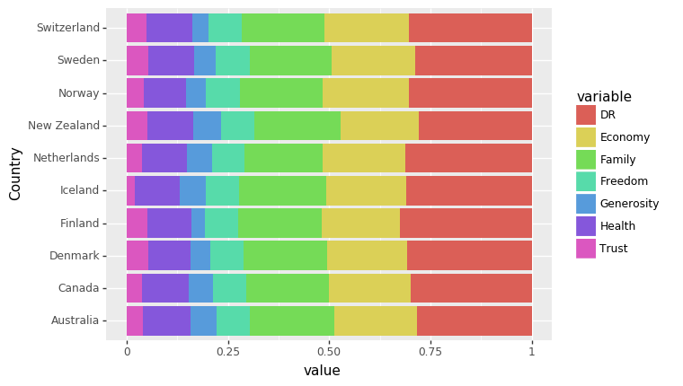

```python
(ggplot(Happy3, aes('Country', 'value', fill='variable')) +
    geom_bar(stat='identity', position='fill') +
    coord_flip())
```

### 2.4 `Eastern Asia`의 연도별 행복지수 요인들 분포

- step별로 진행할 것

#### Step1

- `Region == 'Eastern Asia'`만 필터링하기
- `head()` 출력

```python
Happy >> mask(X.Region == 'Eastern Asia') >> head()
```

|  | Country | DR | Economy | Family | Freedom | Generosity | H_Rank | H_Score | Health | Region | Trust | year |
| --- | --- | --- | --- | --- | --- | --- | --- | --- | --- | --- | --- | --- |
| 37 | Taiwan | 2.32323 | 1.29098 | 1.07617 | 0.39740 | 0.25376 | 38 | 6.298 | 0.87530 | Eastern Asia | 0.08129 | 2015 |
| 45 | Japan | 1.68435 | 1.27074 | 1.25712 | 0.49615 | 0.10705 | 46 | 5.987 | 0.99111 | Eastern Asia | 0.18060 | 2015 |
| 46 | South Korea | 2.21978 | 1.24461 | 0.95774 | 0.33208 | 0.18557 | 47 | 5.984 | 0.96538 | Eastern Asia | 0.07857 | 2015 |
| 71 | Hong Kong | 0.65429 | 1.38604 | 1.05818 | 0.59608 | 0.39478 | 72 | 5.474 | 1.01328 | Eastern Asia | 0.37124 | 2015 |
| 83 | China | 1.86040 | 0.89012 | 0.94675 | 0.51697 | 0.08185 | 84 | 5.140 | 0.81658 | Eastern Asia | 0.02781 | 2015 |

#### Step2

- Tidy Data 만들기
- id_var: `year`, `Country`
- melt_vars: `DR`, `Economy`, `Family`, `Freedom`, `Generosity`, `Health`, `Trust`
- `head()` 출력

```python
Happy2 = (Happy >> mask(X.Region == 'Eastern Asia')
                >> gather('variable', 'value', ['DR', 'Economy', 'Family', 'Freedom', 'Generosity', 'Health',  'Trust'])
                >> select('year', 'Country', 'variable', 'value') )
Happy2.head()
```

|  | year | Country | variable | value |
| --- | --- | --- | --- | --- |
| 0 | 2015 | Taiwan | DR | 2.32323 |
| 1 | 2015 | Japan | DR | 1.68435 |
| 2 | 2015 | South Korea | DR | 2.21978 |
| 3 | 2015 | Hong Kong | DR | 0.65429 |
| 4 | 2015 | China | DR | 1.86040 |

#### Step3

- density plot 그리기
- `fill`은 `variable`을 기준으로 하기
- `alpha`는 0.3

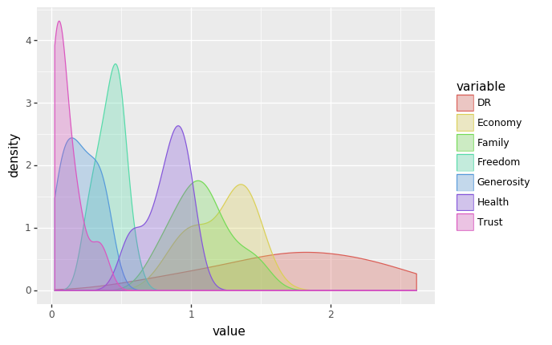

```python
(ggplot(Happy2, aes('value', fill='variable', color='variable')) +
     geom_density(alpha=0.3))
```

#### Step4

- facet_wrap 활용하여 연도별 분포 보기

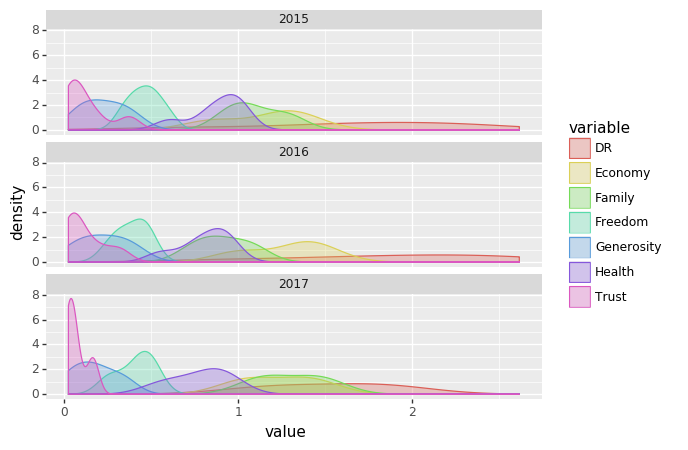

```python
(ggplot(Happy2, aes('value', fill='variable', color='variable')) +
     geom_density(alpha=0.3) +
     facet_wrap('year', nrow=3))
```